# World Cup 2026 Predictor

Gillard BT

Updated: 2026-06-28

```
## [1] "All entries are correctly formatted: TRUE"
```

**Welcome to the World Cup 2026 Predictor Championship!** The aim of the game is simple, predict the scores for all of the group stage games at this year’s tournament. Each correct *score* earns 3 points. Each correct *result* earns 1 point.

**WE ARE LIVE!** All entries have been fed into the predictor machine and there is nothing left to do except watch how your predictions turn out.

We have **37 players** involved so we have a healthy kitty to pay out for the **top 6 players. £81.4 goes to the top dog. £44.4 for the top loser. £25.9 for the best of the rest. And £11.1 for 4th, 5th, and 6th places.** *Although the bragging rights remain the most valuable prize.*

On the Leaderboard you’ll see some extra players included in red. The *RandomControlEntry* predictions were generated randomly using the macro included in the spreadsheet. So if you have fewer points than RandomControlEntry, any thought you put into your entry was an utter waste of time. There are also 2 AI generated entries (*ChatGPT* and *Claude*) that were completed a week before the tournament started to show how powerful the computers are - although they both originally predicted scores for teams that didn’t even qualify. [ESPN](https://www.espn.co.uk/football/story/_/id/48962628/world-cup-predictions-picking-winner-every-game-entire-tournament) have predicted all the group stage and are in the table as *MickeyMouse* in respect to their overlords.

Go to Results Tracker for a more in depth look at which games scored you points.

Forgot what you put for an upcoming game? Want to see what your bitter rival predicted too? Go to the Entry Reminder section and use the drop down to find full predictions for a specific player. Or if you want a general idea of the split of opinion for the next few matches go to Upcoming Games.

To see players who have been immortalised by victory in previous tournaments, see the Predictor Hall of Fame.

**There is a Predictor Whatsapp group! It’s the best place to gloat/cry about your guesses. Click [here](https://chat.whatsapp.com/DlxhlOMRrhD1AbIVlo6Tk6) to join the group. Or scan the QR code below.**

[figure not shown]

# Leaderboard

How things stand after **72 games out of 72**. At the end of the game (Match Day 72(!) on 28th June 2026), winners will be contacted by email for their details so they can receive their hard fought winnings.

Correct games shows how many games you have scored points from (correct scores and results combined).

Table of Champions

|  | Player | Points | CorrectScore | CorrectResult | CorrectGames |
| --- | --- | --- | --- | --- | --- |
| 1 | EdC | 66 | 10 | 36 | 64% |
| 2 | JessicaTurner | 66 | 10 | 36 | 64% |
| 3 | JordanRichards | 64 | 12 | 28 | 56% |
| 4 | Lowri | 63 | 10 | 33 | 60% |
| 5 | PaulBishop | 63 | 9 | 36 | 62% |
| 6 | TobyGillard | 63 | 8 | 39 | 65% |
| 7 | IanRandles | 62 | 9 | 35 | 61% |
| 8 | GeorgeBatho(George1) | 61 | 9 | 34 | 60% |
| 9 | JasonJohnson | 61 | 9 | 34 | 60% |
| 10 | YvonneKershaw | 60 | 10 | 30 | 56% |
| 11 | Swaff | 60 | 9 | 33 | 58% |
| 12 | MicheleCarrabba | 59 | 8 | 35 | 60% |
| 13 | MartinNewcomb | 59 | 8 | 35 | 60% |
| 14 | Justyna | 59 | 7 | 38 | 62% |
| 15 | PaulNewcomb | 58 | 8 | 34 | 58% |
| 16 | AndriChristodoulou | 56 | 8 | 32 | 56% |
| 17 | ChatGPT | 56 | 7 | 35 | 58% |
| 18 | GeorgiaAtkinson | 56 | 5 | 41 | 64% |
| 19 | ColinMurphy | 55 | 7 | 34 | 57% |
| 20 | LewisEvans | 55 | 7 | 34 | 57% |
| 21 | SimonScoltock | 54 | 8 | 30 | 53% |
| 22 | Army’sBarmyArmy | 54 | 8 | 30 | 53% |
| 23 | BIGAL | 54 | 6 | 36 | 58% |
| 24 | Jake | 54 | 6 | 36 | 58% |
| 25 | JulieGillard | 54 | 5 | 39 | 61% |
| 26 | HelenAnglin-Labiak | 52 | 8 | 28 | 50% |
| 27 | HarryPew | 52 | 6 | 34 | 56% |
| 28 | MickeyMouse | 52 | 6 | 34 | 56% |
| 29 | DáireShanahan | 51 | 6 | 33 | 54% |
| 30 | CarlaWright | 51 | 5 | 36 | 57% |
| 31 | LeeGammon | 51 | 3 | 42 | 62% |
| 32 | Mitch | 50 | 6 | 32 | 53% |
| 33 | SueChristie | 50 | 5 | 35 | 56% |
| 34 | BenjaminFlynn | 48 | 8 | 24 | 44% |
| 35 | AndyDickens | 48 | 5 | 33 | 53% |
| 36 | MartynGillard | 48 | 2 | 42 | 61% |
| 37 | Genevieve | 43 | 4 | 31 | 49% |
| 38 | DrBenGillard | 43 | 3 | 34 | 51% |
| 39 | CHodgson | 34 | 3 | 25 | 39% |
| 40 | Claude | 28 | 3 | 19 | 31% |
| 41 | RandomControlEntry | 24 | 1 | 21 | 31% |

> When 2 players have the same points tally, correct scores are taken into account. If players are still equal, the tie break question “How many total goals (including knockout games but excluding penalty shoot outs) will England score at the 2026 World Cup?” will come into play. Closest wins.

## England Goals (tie breaker)

Tracks the tie break question of how many goals England will score. The TrueGoals are updated after every [England game](https://www.youtube.com/watch?v=RJqimlFcJsM).

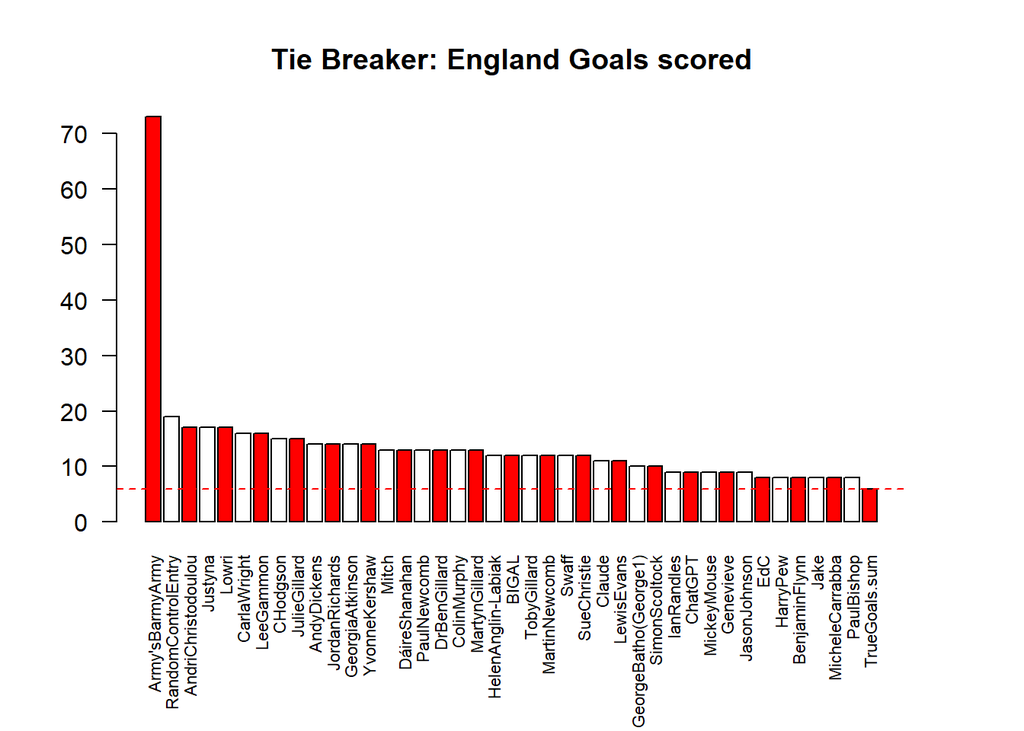

# Hypothetical Tournament

Who do we, as a collective of Mystic Megs, predict will be the winners and losers in the group stage? This plot shows how many times each team has been predicted to win a match in the group stages.

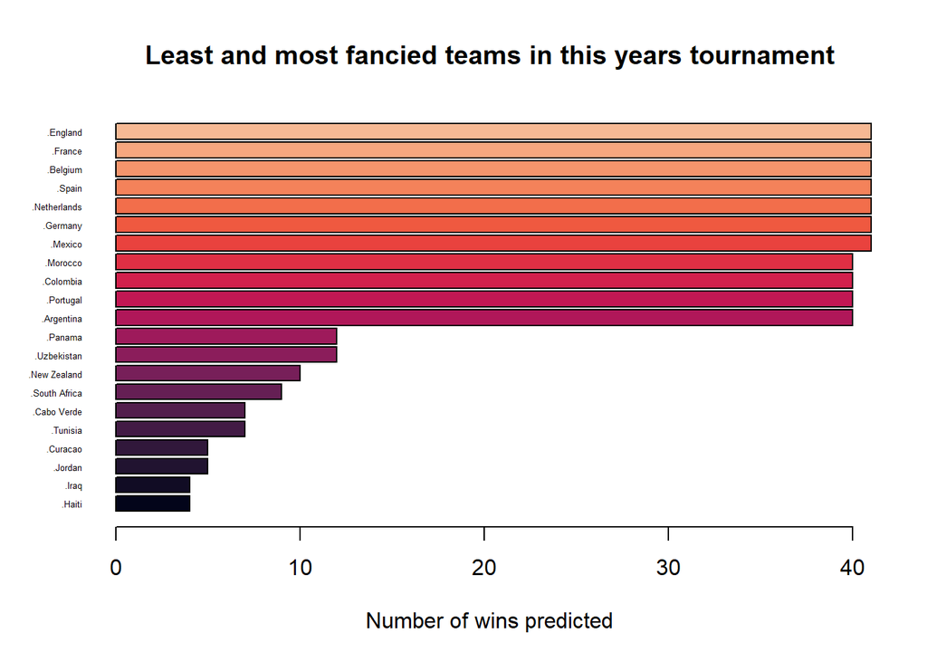

More specifically, how many times does each player think selected nations will win in the group stage (more teams available on request)? How many boring draws do people think we’ll suffer through? Alternatively, are players expecting a goalfest?

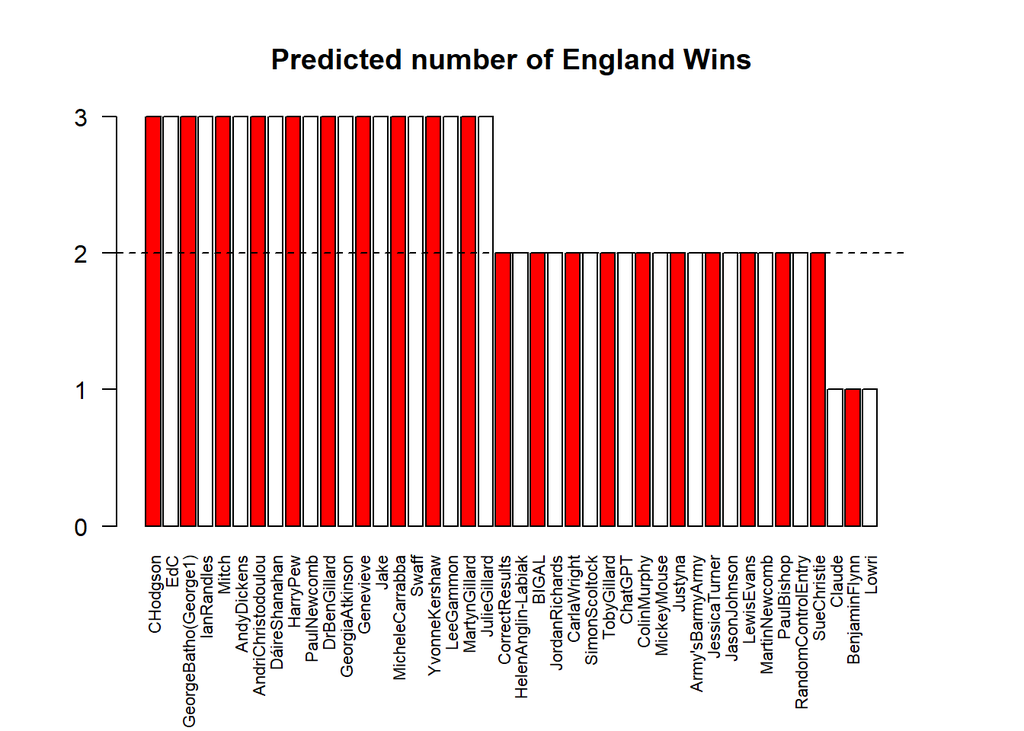

[figure not shown]

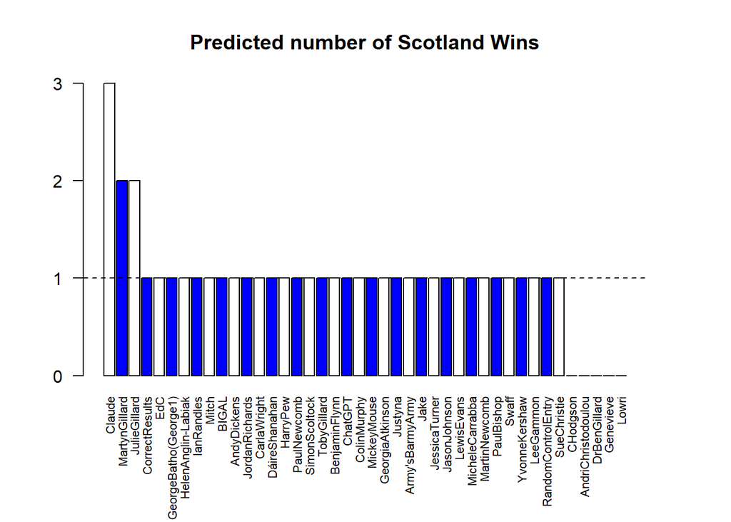

[figure not shown]

[figure not shown]

[figure not shown]

# Results Tracker

This Results Tracker has a bit more depth than the Leaderboard. It shows what points everyone has scored for each game.

Hover over each tile for more information (might not work on phones). Green = Correct Score (3 points), Yellow = Correct Result (1 point), Grey = Wrong! (nil pois).

[interactive chart not shown]

# Upcoming Games

# Entry reminder

If you’ve forgotten what you entered or want to be nosy and see what your rival predicted for an upcoming game, you can find all entry data in the app below:

[interactive chart not shown]

# Predictor Hall of Fame

A small internet shrine for those that have blazed a trail of glory in previous predictor games.

World Cup 2018

| Position | Player |
| --- | --- |
| 1 | Phil Griffiths |
| 2 | Polly Wallace |
| 3 | Justyna |

Euro 2020

| Position | Player |
| --- | --- |
| 1 | Paul Newcomb |
| 2 | Lee Gammon |
| 3 | Martin Newcomb |

World Cup 2022

| Position | Player |
| --- | --- |
| 1 | Jon Williams |
| 2 | Paul Newcomb |
| 3 | Lewis Evans |

Euro 2024

| Position | Player |
| --- | --- |
| 1 | Paul Newcomb |
| 2 | Martin Newcomb |
| 3 | Ben Flynn |

World Cup 2026

| Position | Player |
| --- | --- |
| 1 | Ed C |
| 2 | Jessica Turner |
| 3 | Jordan Richards |

This webpage and the predictor game is maintained by Dr Ben Gillard. If you spot any bugs or have any ideas for improvements please contact me at benspredictorgame@gmail.com